# Mindste kvadraters metode og kvadratiske former

# Introduktion

I skal nu kigge på ‘koordinatskift’ mellem to kort. Man kan tænke på at skifte fra koordinater mht. kortene DKTM og UTM eller måske mellem projektionerne for Femern Bælt og DKTM3 eller en lokal projektion, jeres firma har lavet. Omregning af koordinater og eksempler på systemer i Danmark kan f.eks. findes i fikspunktsregistret [Valdemar](https://valdemar.dataforsyningen.dk/).

Vi ønsker at bestemme en afbildning, som til ethvert punkt med koordinater $(u,v)$ i det ene kort giver koordinaterne $\big(x(u,v), y(y,v)\big)$ i det andet kort. Funktionerne $x(u,v)$ og $y(u,v)$ skal være andengradspolynomier. Vi tænker på disse polynomier som en tilnærmelse til ‘den rigtige’ koordinattransformation, ligesom i tidligere har set tangentlinje som tilnærmelse til en funktion i et punkt.[^1]

Vi kender koordinatoversættelsen i nogle punkter
$$(u_1, v_1)\sim (x_1,y_1),\,
(u_2,v_2)\sim (x_2, y_2),\,
\ldots,
(u_k, v_k)\sim (x_k, y_k),$$
som vi så skal bruge til at bestemme afbildningen mellem de to kort. For at få et andengradspolynomium af to variable, skal vi finde en afbildning på formen
$$x(u,v) = c_0 + c_1u + c_2v +c_3u^2 + c_4 v^2 + c_5 uv.$$
Altså har vi seks koefficienter, der skal estimeres for $x$-afbildningen. Tilsvarende har vi seks koefficienter for $y$, så vi samlet set skal bestemme $12$ ubekendte.

På Figur 1 ses den type afbildning i fire forskellige tilfælde. De blå kurver svarer til at holde $u$ konstant, mens de røde kurver svarer til at holde $v$ konstant. Læg mærke til, at konformiteten gør, at de blå og røde kurver altid skærer hinanden vinkelret. Det sidste eksempel viser en rotation, som er en lineær afbildning.

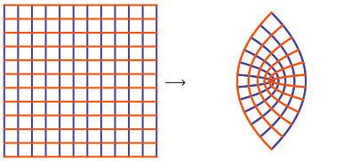

$\mathbf{a}=[0,0,1], \mathbf{b}=\mathbf{0}$

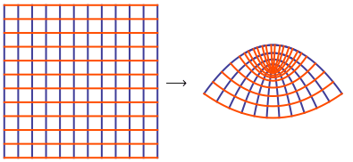

$\mathbf{a}=[0,1,0], \mathbf{b}=[0,1,1]$

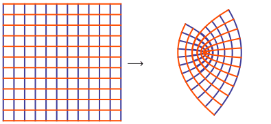

$\mathbf{a}=[0,2,1], \mathbf{b}=[0,1,0]$

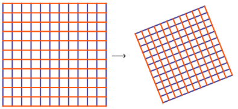

$\mathbf{a}=[0,2,0], \mathbf{b}=[0,5,0]$

Figur 1: Illustrationer af koordinatskift. Vektorerne $\mathbf{a}$ og $\mathbf{b}$ angiver koefficienterne i Ligning 1.

# Delopgave 1

1. Lad $A$ være en $2k\times 6$-matrix givet ud fra data:
   $$A=
   \begin{bmatrix}
   1 & 0& u_1&-v_1&u_1^2-v_1^2&-2u_1v_1\\
   0&1 &v_1&u_1&2u_1v_1&u_1^2-v_1^2\\
   1 & 0& u_2&-v_2&u_2^2-v_2^2&-2u_2v_2\\
   0&1 &v_2&u_2&2u_2v_2&u_2^2-v_2^2\\
   \vdots & \vdots& \vdots & \vdots&\vdots&\vdots\\
   1 & 0& u_k&-v_k&u_k^2-v_k^2&-2u_kv_k\\
   0&1 &v_k&u_k&2u_kv_k&u_k^2-v_k^2
   \end{bmatrix}.$$

   Vi indfører notationen $\mathbf{x}=[a_0,b_0,a_1,b_1,a_2,b_2]^\top$ og $\mathbf{b}=[x_1,y_1, x_2,y_2, \ldots, x_k,y_k]^\top$. Vis, at Ligning 2 da kan omskrives til
   $$F(\mathbf{x}) = \lVert \mathbf{b} - A\mathbf{x}\rVert^2.$$

   Et minimum for $F(\mathbf{x})$ er dermed en vektor $\hat{\mathbf{x}}$, som opfylder $\lVert\mathbf{x}-A\hat{\mathbf{x}}\rVert \leq \lVert\mathbf{b}-A\mathbf{x}\rVert$ for alle $\mathbf{x}$. Per definition betyder dette, at $\hat{\mathbf{x}}$ er en mindste kvadraters løsning til matrixligningen $A\mathbf{x}=\mathbf{b}$.
2. Normalligningen for dette mindste kvadraters problem er
   $$A^\top A\hat{\mathbf{x}} = A^\top \mathbf{b}.$$

   Hvad er betingelsen for, at der eksisterer en *entydig* løsning til denne ligning? Hvor mange datapunkter skal vi mindst have, for at dette er opfyldt?

   **Vink**

   Find en passende sætning i afsnit 6.5 i lærebogen (Lay, Lay & McDonald).
3. Vi betragter nu et lidt simplere problem, hvor vi antager, at Origo bevares. Gør rede for, at vi da skal løse et mindste kvadraters problem med matricen
   $$B=
   \begin{bmatrix}
   u_1&-v_1&u_1^2-v_1^2&-2u_1v_1\\
   v_1&u_1&2u_1v_1&u_1^2-v_1^2\\
   u_2&-v_2&u_2^2-v_2^2&-2u_2v_2\\
   v_2&u_2&2u_2v_2&u_2^2-v_2^2\\
   \vdots & \vdots &\vdots &\vdots\\
   u_k&-v_k&u_k^2-v_k^2&-2u_kv_k\\
   v_k&u_k&2u_kv_k&u_k^2-v_k^2
   \end{bmatrix}$$
4. Antag, at vi har data
   $$\begin{align*}
   (u_1,v_1,x_1,y_1) &=(1,0,2,0)\\
   (u_2,v_2,x_2,y_2) &=(0,1,1,-1)\\
   (u_3,v_3,x_3,y_3) &=(1,1,-2,2).
   \end{align*}$$

   Opskriv den $6\times 4$-matrix, der svarer til $B$, og vis, at
   $$B^TB=\begin{bmatrix} 4 & 0 & 3 & -3\\0 & 4 & 3 & 3\\3 & 3 & 6 & 0\\-3 & 3 & 0 & 6\end{bmatrix}$$

   Opstil derefter normalligningen for dette problem.
5. Løses normalligningen ovenfor, får man $\hat{\mathbf{x}}=[1,-2,4/3, 7/3]^\top$. Gør rede for, at dette svarer til den approksimerede funktion
   $$\left[
   \begin{array}{c}
   x(u,v)\\ y(u,v)
   \end{array}
   \right]
   =
   \left[
   \begin{array}{c}
   u +2v + \frac{4}{3}(u^2-v^2) -2\cdot\frac{7}{3}uv\\
   -2u + v + \frac{7}{3}(u^2-u^2)+2\cdot\frac{4}{3}uv
   \end{array}
   \right].$$

   Indsæt de tre punkter $(u_i, v_i)$ og find afstandene fra $\big(x(u_i,v_i), y(u_i,v_i)\big)$ til dataværdierne $(x_i,y_i)$. Find den samlede kvadratiske afstand $F(0,0,1,-2,4/3, 7/3)$.

   Tegn punkterne $(x_i,y_i)$ og $\big(x(u_i,v_i), y(u_i,v_i)\big)$ ind i et plant koordinatsystem (I må gerne bbruge Python, GeoGebra eller et andet CAS-værktøj).

   **Facit**

   De estimerede koordinater er
   $$\begin{align*}
   \big(x(u_1,v_1), y(u_1,v_1)\big) &= \left(\frac{7}{3}, \frac{1}{3}\right)\\
   \big(x(u_i,v_i), y(u_i,v_i)\big) &= \left(\frac{2}{3}, -\frac{4}{3}\right)\\
   \big(x(u_i,v_i), y(u_i,v_i)\big) &= \left(-\frac{5}{3}, \frac{5}{3}\right).
   \end{align*}$$

# Delopgave 2

Vi vender nu tilbage til målforholdet, som I så på i blok 2. For den lineære afbildning $\mathbf{x}\mapsto B\mathbf{x}$ er målforholdet i retning $\mathbf{v}$ givet ved $m(B,\mathbf{v}) = \sqrt{\frac{\mathbf{v}\cdot B^\top B\mathbf{v}}{\mathbf{v}\cdot\mathbf{v}}}$.

1. Gør rede for, at tælleren $\mathbf{v}\cdot B^\top B\mathbf{v}$ er en kvadratisk form. Notér denne med $Q_B$.
2. Brug at $\lVert B\mathbf{v}\rVert^2 = \mathbf{v}\cdot B^\top B\mathbf{v}$ til at indse, at $Q_B$ er positivt semidefinit.

   **Vink**

   Kan man få $\lVert B\mathbf{v}\rVert^2<0$?
3. Argumenter for følgende udsagn: Hvis der eksisterer et $\mathbf{v}\neq\mathbf{0}$, som opfylder $Q_B(\mathbf{v})=\mathbf{0}$, så er $B\mathbf{v}=\mathbf{0}$.

   Konkluder deraf, at $Q_B$ er positivt definit, hvis $\mathrm{Null}(B) = \{\mathbf{0}\}$.

# Delopgave 3

I Delopgave 1 regnede I på det simplificerede problem med matricen $B$. I skal nu bruge Python til at løse det oprindelige problem med matricen $A$.

   **Vink**

   **Vink**

   Man kan f.eks. bruge `numpy.linalg.det(A)` til at udregne determinanten eller `sympy.Matrix(A).rref()` til at bestemme den reducerede trappeform.
4. Vi tilføjer nu to ekstra datapunkter
   $$(u_4,v_4,x_4,y_4) = (0,0,0,0),\quad
   (u_5,v_4,x_4,y_4) = (-1,0,-2,2)$$

## Fodnoter

[^1]: Koordinater i den gamle danske projektion *System34*, omregnes til den nye standardrepræsentation UTM/ETRS89 Zone 32 ved at bruge to polynomier af grad 11. Det slipper I for i denne workshop.
[^2]: Det kaldes dermed et *konformt* koordinatskift.

[figure not shown]

Computational Thinking Makes Sense of Mathematics

[figure not shown]